# Árvore de Decisão

Matheus Machado de Almeida

09/06/2021

### Árvore de Decisão no R

Árvore de decisão é um modelo simples e extremamente útil para fazer predições. É fácil de explicar para as pessoas mais alheias ao mundo de ciência de dados e machine learning. Além disso, é simples de identificar o poder preditivo das variáveis, requer pouco pré-processamento, etc. Hoje, vou apresentar o código em R para uma árvore de decisão.

Primeiramente, a ideia aqui é apenas passar o esqueleto que você precisa ter em mãos. Em outras palavras, não teremos teoria, mas você vai poder pegar o código abaixo e trocar os dados pelo que você tiver aí. Tive que fazer um trabalho sobre este tema em uma aula do mestrado e por isso resolvi compartilhá-lo. Nesse exercício, nós tínhamos a informação de um banco alemão (veja o link Statlog (German Credit Data) Data Set contendo as informações a respeito dos clientes) e tínhamos que montar uma árvore de decisão que retornasse se o cliente era um bom ou mau pagador.

O arquivo utilizado no código estava em formato .cvs, que o wordpress aparentemente não suporta pelo método tradicional de adicionar arquivos, então vocês podem pegar o arquivo no formato .xlsx para testarem: german_credit_21.

Não há muito o que comentar aqui, divirtam-se com o código abaixo, sigam os comentários que eu deixei e qualquer dúvida é só comentar o post.

```r
setwd("C:/Users/mathe/Documents/GitHub/EstatSite_R")

require(readxl)
dados <- read_xlsx("german_credit_21-1.xlsx")

library("rpart");
library("ROCR");
```

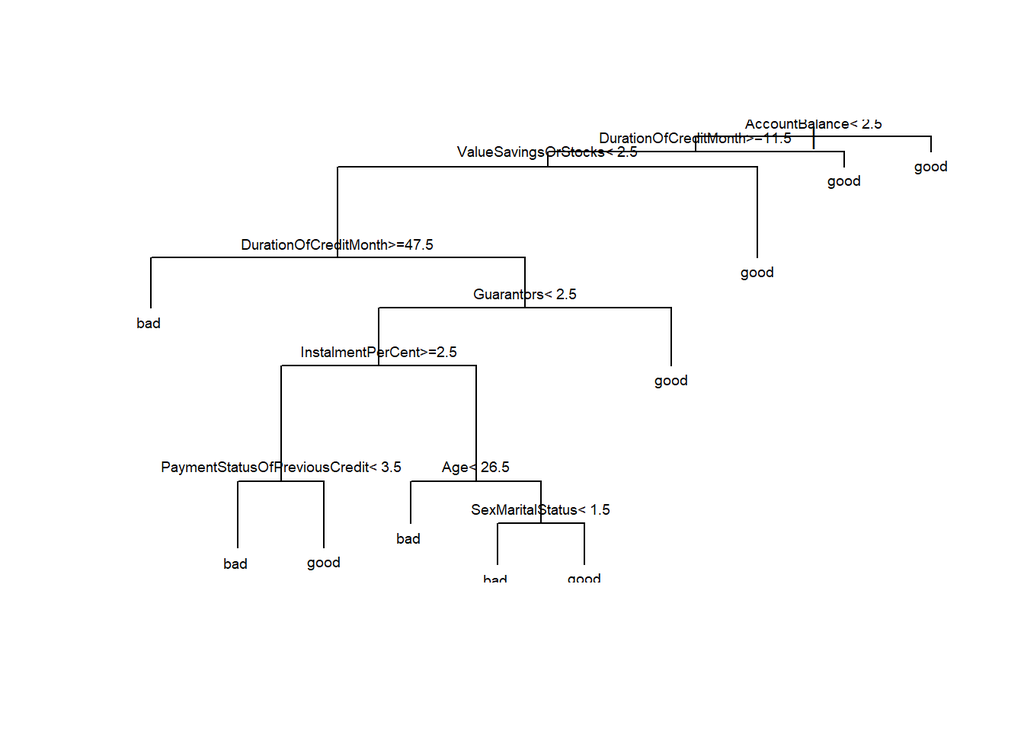

```r
## Discretiza as variaveis
Creditability_index1 = which(dados$Creditability == 1);
Creditability_index2 = which(dados$Creditability == 0);

dados$Creditability[Creditability_index1] = 'good'
dados$Creditability[Creditability_index2] = 'bad'

## ifelse avalia antes de executar
dados$CreditAmount = ifelse(dados$CreditAmount <= 2500,
                            "0-2500",
                            ifelse(dados$CreditAmount < 5000,
                                   "5000+",
                                   "2500-5000")) ;

## Gera indices da base treino e teste
train_index = sample(1:nrow(dados),
                     0.6*nrow(dados),
                     replace = FALSE);

## Gera base treino e teste
train = data.frame();
train = dados[train_index,];
test = data.frame();
test = dados[-train_index,];

## Usa rpart para decision tree
train_tree = rpart(Creditability~.,
                   data = train);

## Plota a árvore de decisão
plot(train_tree);

## Insere a legenda dos galhos
text(train_tree,
     pretty = 0,
     cex = 0.6);
```

```r
## Predict como funcao para trazer a probabilidade do cliente ser mau/bom
test_tree_predict = predict(train_tree,
                            newdata = test);

## Predict com tipo 'classe' retorna se é bom ou mau
test_tree_predict = predict(train_tree,
                            newdata = test,
                            type = "class");

## confusion matrix
table(test_tree_predict,
      test$Creditability)
```

```
##
## test_tree_predict bad good
##              bad   57   33
##              good  68  242
```